# Reproducible Research: Peer Assessment 1

## Loading and preprocessing the data

```r
library(dplyr,quietly=TRUE)
act <- read.csv("activity.csv")
```

## What is mean total number of steps taken per day?

1. Calculate the total number of steps taken per day

```r
by_date <- group_by(act,date)
step_data <- summarise(by_date,tot_steps=sum(steps,na.rm=TRUE))
```

2. Make a histogram of the total number of steps taken each day

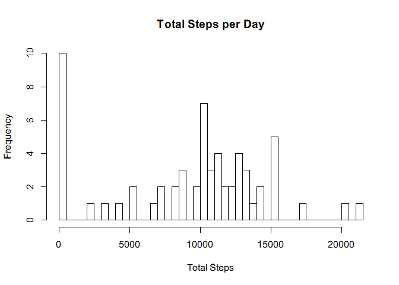

```r
hist(step_data$tot_steps,breaks=nrow(step_data),main="Total Steps per Day",xlab="Total Steps")
```

3. Calculate and report the mean and median of the total number of steps taken per day

```r
step_data <- cbind(step_data,
                   summarise(by_date,mean_steps=mean(steps,na.rm=TRUE))$mean_steps,
                   summarise(by_date,med_steps=median(steps,na.rm=TRUE))$med_steps )

colnames(step_data) <-c("date","tot_steps","mean_steps","med_steps")
step_data[,c("date","mean_steps","med_steps")]
```

```
##          date mean_steps med_steps
## 1  2012-10-01        NaN        NA
## 2  2012-10-02  0.4375000         0
## 3  2012-10-03 39.4166667         0
## 4  2012-10-04 42.0694444         0
## 5  2012-10-05 46.1597222         0
## 6  2012-10-06 53.5416667         0
## 7  2012-10-07 38.2465278         0
## 8  2012-10-08        NaN        NA
## 9  2012-10-09 44.4826389         0
## 10 2012-10-10 34.3750000         0
## 11 2012-10-11 35.7777778         0
## 12 2012-10-12 60.3541667         0
## 13 2012-10-13 43.1458333         0
## 14 2012-10-14 52.4236111         0
```

[output cut: 47 more lines]

## What is the average daily activity pattern?

1. Make a time series plot (i.e. type = “l”) of the 5-minute interval (x-axis) and the average number of steps taken, averaged across all days (y-axis)

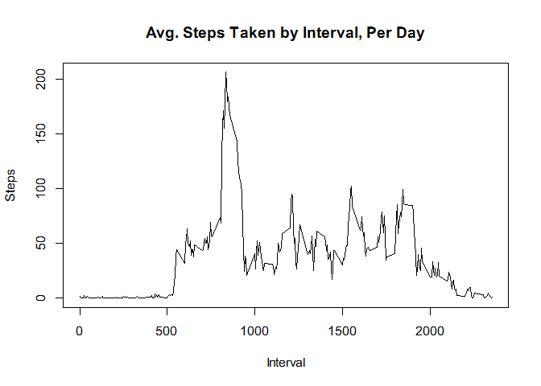

```r
interval <- summarise(group_by(act,interval),
                      mean(steps,na.rm=TRUE),
                      sum(steps,na.rm=TRUE))
colnames(interval) <- c("interval","average","total")

plot(interval$interval,
     interval$average,
     xlab="Interval",
     ylab="Steps",
     type="l",
     main="Avg. Steps Taken by Interval, Per Day")
```

2. Which 5-minute interval, on average across all the days in the dataset, contains the maximum number of steps?

```r
interval$interval[which.max(interval$average)]
```

```
## [1] 835
```

## Imputing missing values

1. Calculate and report the total number of missing values in the dataset (i.e. the total number of rows with NAs)

```r
sum(is.na(act$steps))
```

```
## [1] 2304
```

2. Devise a strategy for filling in all of the missing values in the dataset. The strategy does not need to be sophisticated. For example, you could use the mean/median for that day, or the mean for that 5-minute interval, etc.
3. Create a new dataset that is equal to the original dataset but with the missing data filled in.
4. Make a histogram of the total number of steps taken each day and Calculate and report the mean and median total number of steps taken per day. Do these values differ from the estimates from the first part of the assignment? What is the impact of imputing missing data on the estimates of the total daily number of steps?

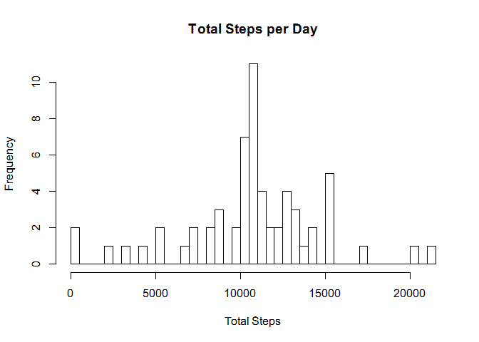

```r
act2 <- act
act2$steps[which(is.na(act2$steps))] <- mean(act2$steps,na.rm=TRUE)
by_date2 <- group_by(act2,date)
step_data2 <- summarise(by_date2,tot_steps=sum(steps,na.rm=TRUE))
hist(step_data2$tot_steps,breaks=nrow(step_data2),main="Total Steps per Day",xlab="Total Steps")
```

```r
step_data2 <- cbind(step_data2,
                   summarise(by_date2,mean_steps=mean(steps,na.rm=TRUE))$mean_steps,
                   summarise(by_date2,med_steps=median(steps,na.rm=TRUE))$med_steps )

colnames(step_data2) <-c("date","tot_steps","mean_steps","med_steps")
step_data2[,c("date","mean_steps","med_steps")]
```

```
##          date mean_steps med_steps
## 1  2012-10-01 37.3825996   37.3826
## 2  2012-10-02  0.4375000    0.0000
## 3  2012-10-03 39.4166667    0.0000
## 4  2012-10-04 42.0694444    0.0000
## 5  2012-10-05 46.1597222    0.0000
## 6  2012-10-06 53.5416667    0.0000
## 7  2012-10-07 38.2465278    0.0000
## 8  2012-10-08 37.3825996   37.3826
## 9  2012-10-09 44.4826389    0.0000
## 10 2012-10-10 34.3750000    0.0000
## 11 2012-10-11 35.7777778    0.0000
## 12 2012-10-12 60.3541667    0.0000
## 13 2012-10-13 43.1458333    0.0000
## 14 2012-10-14 52.4236111    0.0000
```

[output cut: 47 more lines]